# 6. Pandas: Wrangling Operations and Data Visualization

Excel is the most commonly used data analysis software in the world- easy to get a hang off and use

Python with a library like `Pandas` is a good way to build scale in business analytics. Here are some reasons:

- Ability to work with large data sets is much faster and easier
- Ability to read and work with almost any kind of data.
- Automate repetitive tasks are easier.
- Increase reproducability of work.
- Find and fix errors easier.
- Supports statistics and machine learning capabilities.
- Advanced data visualization capabilities.
- Cross-platform stability — your analysis can be run on any computer.

# 6.1 Joining Data Frames

`pandas` provides various facilities for easily combining together Series or DataFrame with various kinds of set logic for the indexes and relational algebra functionality in the case of join / merge-type operations

```python
import pandas as pd
import numpy as np
```

## 6.1.1 Merge

- `merge()`is used to combine two (or more) dataframes on the basis of values of common columns or indexes as in a RDBMS
- If joining columns on columns, the DataFrame indexes will be ignored.
  - Otherwise if joining indexes on indexes or indexes on a column or columns, the index will be passed on

[figure not shown]

```python
np.random.seed(42)
left = pd.DataFrame({'key': ['a', 'b', 'c', 'd', 'e'],
                     'dim1':['grp1', 'grp2','grp2','grp3','grp3'],
                     'values': np.random.normal(65,10,5)})
print(left)
```

```
  key  dim1     values
0   a  grp1  69.967142
1   b  grp2  63.617357
2   c  grp2  71.476885
3   d  grp3  80.230299
4   e  grp3  62.658466
```

```python
np.random.seed(42)
right = pd.DataFrame({'key': ['a','b','c','x','y','z'],
                      'dim2':['aaa', 'aaa','bbb','bbb', 'ccc', 'aaa'],
                      'values': np.random.randint(100, 150, 6)})
print(right)
```

```
  key dim2  values
0   a  aaa     138
1   b  aaa     128
2   c  bbb     114
3   x  bbb     142
4   y  ccc     107
5   z  aaa     120
```

If you want more details on generating data using numpy to generate various types of data please see this [tutorial](https://realpython.com/python-random/)

### 6.1.1.2 inner join

```python
left
```

|  | key | dim1 | values |
| --- | --- | --- | --- |
| 0 | a | grp1 | 69.967142 |
| 1 | b | grp2 | 63.617357 |
| 2 | c | grp2 | 71.476885 |
| 3 | d | grp3 | 80.230299 |
| 4 | e | grp3 | 62.658466 |

```python
right
```

|  | key | dim2 | values |
| --- | --- | --- | --- |
| 0 | a | aaa | 138 |
| 1 | b | aaa | 128 |
| 2 | c | bbb | 114 |
| 3 | x | bbb | 142 |
| 4 | y | ccc | 107 |
| 5 | z | aaa | 120 |

```python
pd.merge(left,right,how='inner',on='key',)
```

|  | key | dim1 | values_x | dim2 | values_y |
| --- | --- | --- | --- | --- | --- |
| 0 | a | grp1 | 69.967142 | aaa | 138 |
| 1 | b | grp2 | 63.617357 | aaa | 128 |
| 2 | c | grp2 | 71.476885 | bbb | 114 |

```python
pd.merge(left, right, how='inner', right_index=True, left_index=True, suffixes=('_left', '_right'))
```

|  | key_left | dim1 | values_left | key_right | dim2 | values_right |
| --- | --- | --- | --- | --- | --- | --- |
| 0 | a | grp1 | 69.967142 | a | aaa | 138 |
| 1 | b | grp2 | 63.617357 | b | aaa | 128 |
| 2 | c | grp2 | 71.476885 | c | bbb | 114 |
| 3 | d | grp3 | 80.230299 | x | bbb | 142 |
| 4 | e | grp3 | 62.658466 | y | ccc | 107 |

### 6.1.1.3 left join

```python
pd.merge(left,right,how='left',on='key')
```

|  | key | dim1 | values_x | dim2 | values_y |
| --- | --- | --- | --- | --- | --- |
| 0 | a | grp1 | 69.967142 | aaa | 138.0 |
| 1 | b | grp2 | 63.617357 | aaa | 128.0 |
| 2 | c | grp2 | 71.476885 | bbb | 114.0 |
| 3 | d | grp3 | 80.230299 | NaN | NaN |
| 4 | e | grp3 | 62.658466 | NaN | NaN |

```python
df= pd.merge(left,right,how='left',on='key')
```

```python
df.isna().sum()
```

```
key         0
dim1        0
values_x    0
dim2        2
values_y    2
dtype: int64
```

```python
pd.merge(left,right, left_index=True, right_index=True, how='left')
```

|  | key_x | dim1 | values_x | key_y | dim2 | values_y |
| --- | --- | --- | --- | --- | --- | --- |
| 0 | a | grp1 | 69.967142 | a | aaa | 138 |
| 1 | b | grp2 | 63.617357 | b | aaa | 128 |
| 2 | c | grp2 | 71.476885 | c | bbb | 114 |
| 3 | d | grp3 | 80.230299 | x | bbb | 142 |
| 4 | e | grp3 | 62.658466 | y | ccc | 107 |

### 6.1.1.4 right join

```python
pd.merge(left,right,how='right',on='key')
```

|  | key | dim1 | values_x | dim2 | values_y |
| --- | --- | --- | --- | --- | --- |
| 0 | a | grp1 | 69.967142 | aaa | 138 |
| 1 | b | grp2 | 63.617357 | aaa | 128 |
| 2 | c | grp2 | 71.476885 | bbb | 114 |
| 3 | x | NaN | NaN | bbb | 142 |
| 4 | y | NaN | NaN | ccc | 107 |
| 5 | z | NaN | NaN | aaa | 120 |

### 6.1.1.5 outer join

```python
pd.merge(left,right,how='outer',on='key')
```

|  | key | dim1 | values_x | dim2 | values_y |
| --- | --- | --- | --- | --- | --- |
| 0 | a | grp1 | 69.967142 | aaa | 138.0 |
| 1 | b | grp2 | 63.617357 | aaa | 128.0 |
| 2 | c | grp2 | 71.476885 | bbb | 114.0 |
| 3 | d | grp3 | 80.230299 | NaN | NaN |
| 4 | e | grp3 | 62.658466 | NaN | NaN |
| 5 | x | NaN | NaN | bbb | 142.0 |
| 6 | y | NaN | NaN | ccc | 107.0 |
| 7 | z | NaN | NaN | aaa | 120.0 |

```python
pd.merge(left,right, how='outer',left_index=True, right_index=True)
```

|  | key_x | dim1 | values_x | key_y | dim2 | values_y |
| --- | --- | --- | --- | --- | --- | --- |
| 0 | a | grp1 | 69.967142 | a | aaa | 138 |
| 1 | b | grp2 | 63.617357 | b | aaa | 128 |
| 2 | c | grp2 | 71.476885 | c | bbb | 114 |
| 3 | d | grp3 | 80.230299 | x | bbb | 142 |
| 4 | e | grp3 | 62.658466 | y | ccc | 107 |
| 5 | NaN | NaN | NaN | z | aaa | 120 |

## 6.1.2 Concat

`concat()` is used to append one (or more) dataframes one below the other (or sideways, depending on whether the axis option is set to `0 or 1`

```python
type([1,2])
```

```
list
```

```python
pd.concat([left, right], axis=0)
```

|  | key | dim1 | values | dim2 |
| --- | --- | --- | --- | --- |
| 0 | a | grp1 | 69.967142 | NaN |
| 1 | b | grp2 | 63.617357 | NaN |
| 2 | c | grp2 | 71.476885 | NaN |
| 3 | d | grp3 | 80.230299 | NaN |
| 4 | e | grp3 | 62.658466 | NaN |
| 0 | a | NaN | 138.000000 | aaa |
| 1 | b | NaN | 128.000000 | aaa |
| 2 | c | NaN | 114.000000 | bbb |
| 3 | x | NaN | 142.000000 | bbb |
| 4 | y | NaN | 107.000000 | ccc |
| 5 | z | NaN | 120.000000 | aaa |

In the above example indexing is not in order.

```python
pd.concat([left, right], axis=0, ignore_index=True)
```

|  | key | dim1 | values | dim2 |
| --- | --- | --- | --- | --- |
| 0 | a | grp1 | 69.967142 | NaN |
| 1 | b | grp2 | 63.617357 | NaN |
| 2 | c | grp2 | 71.476885 | NaN |
| 3 | d | grp3 | 80.230299 | NaN |
| 4 | e | grp3 | 62.658466 | NaN |
| 5 | a | NaN | 138.000000 | aaa |
| 6 | b | NaN | 128.000000 | aaa |
| 7 | c | NaN | 114.000000 | bbb |
| 8 | x | NaN | 142.000000 | bbb |
| 9 | y | NaN | 107.000000 | ccc |
| 10 | z | NaN | 120.000000 | aaa |

keys: Construct hierarchical index using the passed keys as the outermost level.

```python
df= pd.concat([left, right], axis=0, keys=['left', 'right'])
print(df)
```

```
        key  dim1      values dim2
left  0   a  grp1   69.967142  NaN
      1   b  grp2   63.617357  NaN
      2   c  grp2   71.476885  NaN
      3   d  grp3   80.230299  NaN
      4   e  grp3   62.658466  NaN
right 0   a   NaN  138.000000  aaa
      1   b   NaN  128.000000  aaa
      2   c   NaN  114.000000  bbb
      3   x   NaN  142.000000  bbb
      4   y   NaN  107.000000  ccc
      5   z   NaN  120.000000  aaa
```

```python
s= 'grp2'
left.loc[left.dim1== s]
```

|  | key | dim1 | values |
| --- | --- | --- | --- |
| 1 | b | grp2 | 63.617357 |
| 2 | c | grp2 | 71.476885 |

```python
df.loc['left',:]
```

|  | key | dim1 | values | dim2 |
| --- | --- | --- | --- | --- |
| 0 | a | grp1 | 69.967142 | NaN |
| 1 | b | grp2 | 63.617357 | NaN |
| 2 | c | grp2 | 71.476885 | NaN |
| 3 | d | grp3 | 80.230299 | NaN |
| 4 | e | grp3 | 62.658466 | NaN |

```python
df.loc['right']
```

|  | key | dim1 | values | dim2 |
| --- | --- | --- | --- | --- |
| 0 | a | NaN | 138.0 | aaa |
| 1 | b | NaN | 128.0 | aaa |
| 2 | c | NaN | 114.0 | bbb |
| 3 | x | NaN | 142.0 | bbb |
| 4 | y | NaN | 107.0 | ccc |
| 5 | z | NaN | 120.0 | aaa |

Concatenating column wise

```python
df = pd.concat([left,right],axis=1)
df
```

|  | key | dim1 | values | key | dim2 | values |
| --- | --- | --- | --- | --- | --- | --- |
| 0 | a | grp1 | 69.967142 | a | aaa | 138 |
| 1 | b | grp2 | 63.617357 | b | aaa | 128 |
| 2 | c | grp2 | 71.476885 | c | bbb | 114 |
| 3 | d | grp3 | 80.230299 | x | bbb | 142 |
| 4 | e | grp3 | 62.658466 | y | ccc | 107 |
| 5 | NaN | NaN | NaN | z | aaa | 120 |

```python
pd.concat([left, right], axis=1, join='outer')
```

|  | key | dim1 | values | key | dim2 | values |
| --- | --- | --- | --- | --- | --- | --- |
| 0 | a | grp1 | 69.967142 | a | aaa | 138 |
| 1 | b | grp2 | 63.617357 | b | aaa | 128 |
| 2 | c | grp2 | 71.476885 | c | bbb | 114 |
| 3 | d | grp3 | 80.230299 | x | bbb | 142 |
| 4 | e | grp3 | 62.658466 | y | ccc | 107 |
| 5 | NaN | NaN | NaN | z | aaa | 120 |

My favorite Application of `.concat()`

```python
# 3 series creatd programmatically
s1= pd.Series(data=[True,False,True,True,False], index=['a', 'b', 'c', 'd','e'])
s2= pd.Series(data=[100.00,110.00,120.00,130.00,75.00], index=['a', 'b', 'c', 'd','e'])
s3= pd.Series(data=['A','B','C','B','A'], index=['a', 'b', 'c', 'd','e'])
# A list of the 3 series
lst_s= [s1,s2,s3]
```

```python
# form a dataframe using the series as columns
df= pd.concat(lst_s, axis=1)
df.columns= ['bool_flag', 'dollars', 'category']
df
```

|  | bool_flag | dollars | category |
| --- | --- | --- | --- |
| a | True | 100.0 | A |
| b | False | 110.0 | B |
| c | True | 120.0 | C |
| d | True | 130.0 | B |
| e | False | 75.0 | A |

# 6.2 Applying functions & aggregation:

- An essential piece of analysis of large data is efficient summarization: computing aggregations like `sum()`, `mean()`, `median()`, `min()`, and `max()`
- A measure that gives insight into the nature of a potentially large dataset.
- Simple aggregations can give you a flavor of your dataset, but often we would prefer to aggregate conditionally on some label or index: this is implemented in the so-called groupby operation.
  - The name "group by" comes from a command in the SQL database language
- *Split, Apply & Combine*: A canonical example of this split-apply-combine operation, where the "apply" is a summation aggregation, is illustrated in this figure:

[figure not shown]

You may find this [interesting](https://jakevdp.github.io/PythonDataScienceHandbook/03.08-aggregation-and-grouping.html)

## 6.2.1 `.groupby()`

Just to make things a little interesting we shall use Basketball team data!

```python
sport_data = {'Team': ['Nets', 'Nets', 'Clippers', 'Clippers', 'Warriors',
         'Warriors', 'Warriors', 'Warriors', 'Nets', 'Lakers', 'Lakers', 'Nets'],
         'Rank': [1, 2, 2, 3, 3,4 ,1 ,1,2 , 4,1,2],
         'Year': [2014,2015,2014,2015,2014,2015,2016,2017,2016,2014,
                  2015,2017],
         'Points':[876,789,863,673,741,812,756,788,694,701,804,690]}
```

```python
df=pd.DataFrame(sport_data)
print (df)
```

```
        Team  Rank  Year  Points
0       Nets     1  2014     876
1       Nets     2  2015     789
2   Clippers     2  2014     863
3   Clippers     3  2015     673
4   Warriors     3  2014     741
5   Warriors     4  2015     812
6   Warriors     1  2016     756
7   Warriors     1  2017     788
8       Nets     2  2016     694
9     Lakers     4  2014     701
10    Lakers     1  2015     804
11      Nets     2  2017     690
```

*What is the total points won by the basketball teams?*

```python
df.groupby(['Team'])['Points'].sum()
```

```
Team
Clippers    1536
Lakers      1505
Nets        3049
Warriors    3097
Name: Points, dtype: int64
```

Output Structure of a `.groupby`

```python
gf= df.groupby(['Team'])['Points'].sum()
print()
print('What data structure is it? \n', type(gf))
print()
print(' What does the index look like? \n', gf.index)
print()
print('Values:',gf.values)
print()
print('Afer reset_index')
af= gf.reset_index()
print()
print('What data structue now? \n', type(af))
print()
print(' What does the index look like? \n', af.index)
print()
print(' What are the columns? \n', af.columns)
```

```
What data structure is it?
 <class 'pandas.core.series.Series'>

 What does the index look like?
 Index(['Clippers', 'Lakers', 'Nets', 'Warriors'], dtype='object', name='Team')

Values: [1536 1505 3049 3097]

Afer reset_index

What data structue now?
 <class 'pandas.core.frame.DataFrame'>

 What does the index look like?
 RangeIndex(start=0, stop=4, step=1)

 What are the columns?
 Index(['Team', 'Points'], dtype='object')
```

```python
af
```

|  | Team | Points |
| --- | --- | --- |
| 0 | Clippers | 1536 |
| 1 | Lakers | 1505 |
| 2 | Nets | 3049 |
| 3 | Warriors | 3097 |

We shall us these propeties when we are making graphs

*What is the yearly total points by the basketball teams?*

```python
df.groupby(['Year', 'Team'])['Points'].sum()
```

```
Year  Team
2014  Clippers    863
      Lakers      701
      Nets        876
      Warriors    741
2015  Clippers    673
      Lakers      804
      Nets        789
      Warriors    812
2016  Nets        694
      Warriors    756
2017  Nets        690
      Warriors    788
Name: Points, dtype: int64
```

*What is the yearly total points by the basketball teams when they were ranked 1?*

```python
df.loc[df.Rank==1].groupby(['Year', 'Team'])['Points'].sum()
```

```
Year  Team
2014  Nets        876
2015  Lakers      804
2016  Warriors    756
2017  Warriors    788
Name: Points, dtype: int64
```

```python
jj=left.merge(right, left_on='key', right_on='key')
```

```python
jj.loc[jj.dim2=='aaa'].groupby(['dim1','dim2'])['values_x', 'values_y'].sum()
```

| dim1 | dim2 | values_x | values_y |
| --- | --- | --- | --- |
| grp1 | aaa | 69.967142 | 138 |
| grp2 | aaa | 63.617357 | 128 |

### 6.2.1.1 `.agg()`

Function to use for aggregating the data. Useful when you have several aggregation functions at the same time passed as a list.

Introduced in `Pandas 0.25.0`, groupby aggregation with relabelling is supported using “named aggregation” with simple tuples. Python tuples are used to provide the column name on which to work on, along with the function to apply.

```python
df.groupby(['Team'])['Points'].agg([np.min, np.max, np.mean,np.std, np.size])
```

| Team | amin | amax | mean | std | size |
| --- | --- | --- | --- | --- | --- |
| Clippers | 673 | 863 | 768.00 | 134.350288 | 2 |
| Lakers | 701 | 804 | 752.50 | 72.831998 | 2 |
| Nets | 690 | 876 | 762.25 | 88.567771 | 4 |
| Warriors | 741 | 812 | 774.25 | 31.899582 | 4 |

The list configuration of function is most common. For other implementation data structure look [here](https://pandas.pydata.org/pandas-docs/stable/reference/api/pandas.DataFrame.agg.html)

Explicitly Labeling Output Columns

```python
df.groupby(['Team']).agg(min_points= ('Points', np.min),max_points= ('Points', np.max), mean_Rank= ('Rank', np.mean))
```

| Team | min_points | max_points | mean_Rank |
| --- | --- | --- | --- |
| Clippers | 673 | 863 | 2.50 |
| Lakers | 701 | 804 | 2.50 |
| Nets | 690 | 876 | 1.75 |
| Warriors | 741 | 812 | 2.25 |

## 6.2.2 `.crosstab()`

Compute a simple cross-tabulation of two (or more) factors. By default computes a frequency table of the factors unless an array of values and an aggregation function are passed.

```python
pd.crosstab(index=df.Team, columns=df.Year)
```

| Year Team | 2014 | 2015 | 2016 | 2017 |
| --- | --- | --- | --- | --- |
| Clippers | 1 | 1 | 0 | 0 |
| Lakers | 1 | 1 | 0 | 0 |
| Nets | 1 | 1 | 1 | 1 |
| Warriors | 1 | 1 | 1 | 1 |

```python
pd.crosstab(index=df['Team'], columns=df['Year'], values=df['Points'], aggfunc='sum')
```

| Year Team | 2014 | 2015 | 2016 | 2017 |
| --- | --- | --- | --- | --- |
| Clippers | 863.0 | 673.0 | NaN | NaN |
| Lakers | 701.0 | 804.0 | NaN | NaN |
| Nets | 876.0 | 789.0 | 694.0 | 690.0 |
| Warriors | 741.0 | 812.0 | 756.0 | 788.0 |

## 6.2.3 `.pivot()`

- Return reshaped DataFrame organized by given index / column values.

Reshape data (produce a “pivot” table) based on column values. Uses unique values from specified index / columns to form axes of the resulting DataFrame. This function does not support data aggregation, multiple values will result in a MultiIndex in the columns.

```python
df.pivot(index='Team', columns='Year', values='Points')
```

| Year Team | 2014 | 2015 | 2016 | 2017 |
| --- | --- | --- | --- | --- |
| Clippers | 863.0 | 673.0 | NaN | NaN |
| Lakers | 701.0 | 804.0 | NaN | NaN |
| Nets | 876.0 | 789.0 | 694.0 | 690.0 |
| Warriors | 741.0 | 812.0 | 756.0 | 788.0 |

```python
df.groupby(['Year', 'Team'])['Points'].sum().reset_index().pivot(index='Team', columns='Year', values='Points')
```

| Year Team | 2014 | 2015 | 2016 | 2017 |
| --- | --- | --- | --- | --- |
| Clippers | 863.0 | 673.0 | NaN | NaN |
| Lakers | 701.0 | 804.0 | NaN | NaN |
| Nets | 876.0 | 789.0 | 694.0 | 690.0 |
| Warriors | 741.0 | 812.0 | 756.0 | 788.0 |

# 6.3 Pandas `.apply()`

-'apply' function along a axis, instad of looping through it.

- While working with tabular data, you must specify an axis you want your function to act on (`0` for columns; and `1` for rows).
- You can apply a defined function or a use the `lambda` function to iterate over the rows of the dataframe

```python
df
```

|  | Team | Rank | Year | Points |
| --- | --- | --- | --- | --- |
| 0 | Nets | 1 | 2014 | 876 |
| 1 | Nets | 2 | 2015 | 789 |
| 2 | Clippers | 2 | 2014 | 863 |
| 3 | Clippers | 3 | 2015 | 673 |
| 4 | Warriors | 3 | 2014 | 741 |
| 5 | Warriors | 4 | 2015 | 812 |
| 6 | Warriors | 1 | 2016 | 756 |
| 7 | Warriors | 1 | 2017 | 788 |
| 8 | Nets | 2 | 2016 | 694 |
| 9 | Lakers | 4 | 2014 | 701 |
| 10 | Lakers | 1 | 2015 | 804 |
| 11 | Nets | 2 | 2017 | 690 |

## 6.3.1 Pandas `.apply()` on single column

```python
def f(x):
  if x >= 806:
    return('High')
  else:
    return('Low')
```

```python
f(900)
```

```
'High'
```

```python
df['Scr_flg']= df.Points.apply(lambda x: f(x))
```

```python
df
```

|  | Team | Rank | Year | Points | Scr_flg |
| --- | --- | --- | --- | --- | --- |
| 0 | Nets | 1 | 2014 | 876 | High |
| 1 | Nets | 2 | 2015 | 789 | Low |
| 2 | Clippers | 2 | 2014 | 863 | High |
| 3 | Clippers | 3 | 2015 | 673 | Low |
| 4 | Warriors | 3 | 2014 | 741 | Low |
| 5 | Warriors | 4 | 2015 | 812 | High |
| 6 | Warriors | 1 | 2016 | 756 | Low |
| 7 | Warriors | 1 | 2017 | 788 | Low |
| 8 | Nets | 2 | 2016 | 694 | Low |
| 9 | Lakers | 4 | 2014 | 701 | Low |
| 10 | Lakers | 1 | 2015 | 804 | Low |
| 11 | Nets | 2 | 2017 | 690 | Low |

## 6.3.2 Pandas `.apply()` on > 1 column

```python
def g(x,y):
  if (x==1) & (y=='High'):
    return('11')
  elif (x!=1) & (y=='High'):
    return('01')
  else:
    return('00')
```

Watchout!! The above function is built to be good for single variables and scalars

```python
g(4, 'Low')
```

```
'00'
```

```python
df['rank_score_flg']=df.apply(lambda x: g(x['Rank'], x['Scr_flg']), axis=1)
```

```python
df
```

|  | Team | Rank | Year | Points | Scr_flg | rank_score_flg |
| --- | --- | --- | --- | --- | --- | --- |
| 0 | Nets | 1 | 2014 | 876 | High | 11 |
| 1 | Nets | 2 | 2015 | 789 | Low | 00 |
| 2 | Clippers | 2 | 2014 | 863 | High | 01 |
| 3 | Clippers | 3 | 2015 | 673 | Low | 00 |
| 4 | Warriors | 3 | 2014 | 741 | Low | 00 |
| 5 | Warriors | 4 | 2015 | 812 | High | 01 |
| 6 | Warriors | 1 | 2016 | 756 | Low | 00 |
| 7 | Warriors | 1 | 2017 | 788 | Low | 00 |
| 8 | Nets | 2 | 2016 | 694 | Low | 00 |
| 9 | Lakers | 4 | 2014 | 701 | Low | 00 |
| 10 | Lakers | 1 | 2015 | 804 | Low | 00 |
| 11 | Nets | 2 | 2017 | 690 | Low | 00 |

# 6.4 Statistical Functions in `pandas`

List of available function that typically finds use

1. `count()` Number of non-null observations
2. `sum()` Sum of values
3. `mean()` Mean of Values [average]
4. `median()` Median of Values [cenral value]
5. `mode()` Mode of values [most common value]
6. `std()` Standard Deviation of the Values [spread of data]
7. `min()` Minimum Value [lowest value]
8. `max()` Maximum Value [Highest value]
9. `abs()` Absolute Value [non-negaive number component]
10. `prod()` Product of Values
11. `cumsum()` Cumulative Sum [running sum by dimension]
12. `cumprod()` Cumulative Product [product and sum]

Note: − Since DataFrame is a Heterogeneous data structure. Generic operations don’t work with all functions.

```python
df.sum()
```

```
Team              NetsNetsClippersClippersWarriorsWarriorsWarrio...
Rank                                                             26
Year                                                          24182
Points                                                         9187
Scr_flg                     HighLowHighLowLowHighLowLowLowLowLowLow
rank_score_flg                             110001000001000000000000
dtype: object
```

```python
df.median( axis=0)
```

```
Rank                 2.0
Year              2015.0
Points             772.0
rank_score_flg       0.0
dtype: float64
```

```python
df.groupby('Team')['Points'].agg('mean')
```

```
Team
Clippers    768.00
Lakers      752.50
Nets        762.25
Warriors    774.25
Name: Points, dtype: float64
```

```python
df.groupby('Team')['Points'].agg('describe')
```

| Team | count | mean | std | min | 25% | 50% | 75% | max |
| --- | --- | --- | --- | --- | --- | --- | --- | --- |
| Clippers | 2.0 | 768.00 | 134.350288 | 673.0 | 720.50 | 768.0 | 815.50 | 863.0 |
| Lakers | 2.0 | 752.50 | 72.831998 | 701.0 | 726.75 | 752.5 | 778.25 | 804.0 |
| Nets | 4.0 | 762.25 | 88.567771 | 690.0 | 693.00 | 741.5 | 810.75 | 876.0 |
| Warriors | 4.0 | 774.25 | 31.899582 | 741.0 | 752.25 | 772.0 | 794.00 | 812.0 |

# 6.5 Plots & Graphs in `pandas`

`matplotlib` is a Python package used for data plotting and visualisation. It is a useful complement to `pandas`, and like `pandas`, is a very feature-rich library which can produce a large variety of plots, charts, maps, and other visualisations.

This section is really to cover basic capabilities of matplotlib in conjunction with `pandas`

```python
import matplotlib.pyplot as plt
```

## 6.5.1 Scatter Plot

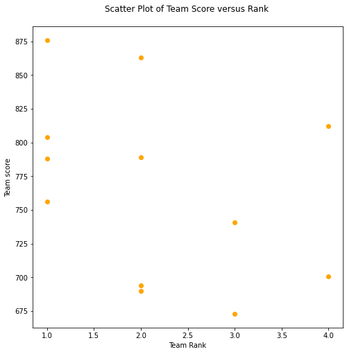

```python
plt.figure(figsize=(8,8))
plt.scatter(df.Rank, df.Points, marker='o', c='orange')
plt.xlabel('Team Rank')
plt.ylabel('Team score')
plt.title('Scatter Plot of Team Score versus Rank \n')
plt.show()
```

## 6.5.2 Bar Graph

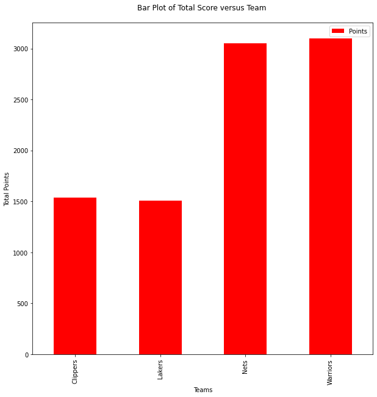

```python
af.plot('Team', 'Points', kind='bar', ylabel='Total Points', xlabel='Teams', color='red', figsize=(10,10),\
        title= 'Bar Plot of Total Score versus Team \n')
```

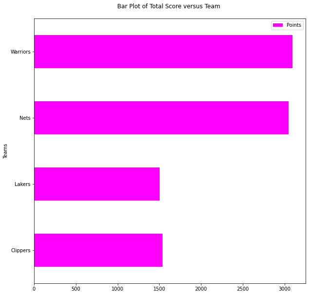

```python
af.plot('Team', 'Points', kind='barh', ylabel='Total Points', xlabel='Teams', color='magenta', figsize=(10,10),\
        title= 'Bar Plot of Total Score versus Team \n')
```

## 6.5.3 Line Graph

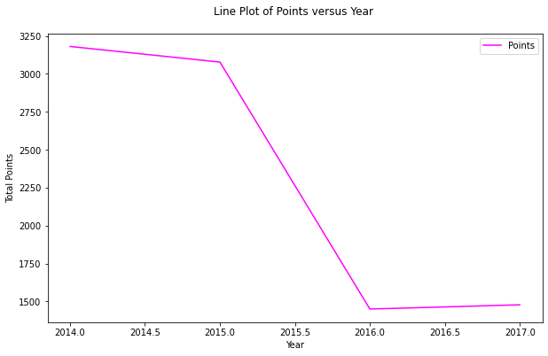

```python
# Sum of Points for every year acros all teams
df.groupby('Year')['Points'].sum().reset_index().\
plot('Year', 'Points', kind='line',ylabel='Total Points', xlabel='Year', \
     color='magenta', figsize=(10,6),title= 'Line Plot of Points versus Year \n')
```

## 6.5.4 Histogram Graph

```
array([[<matplotlib.axes._subplots.AxesSubplot object at 0x7fc25e68cd50>]],
      dtype=object)
```

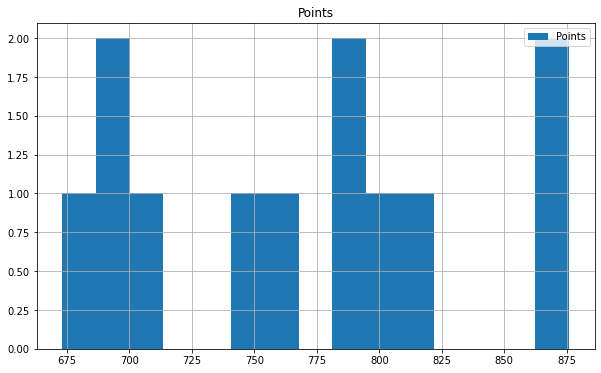

```python
df.hist('Points', bins=15, legend=True, figsize=(10,6))
```

matplotlib https://www.geeksforgeeks.org/display-the-pandas-dataframe-in-heatmap-style/